# Epilepsy Surgery Outcomes Power Review

Adam S Dickey

5/18/2022

### Load raw data

I will load the data from the Excel spreadsheet and show the first 6 rows.

```r
samplesize <- read_excel("Dickey Appendix S1.xlsx")
head(samplesize)
```

```
## # A tibble: 6 × 14
##      ID First_Author  Year Journal   Short_title    nTot    nA    nB  Apos  Aneg
##   <dbl> <chr>        <dbl> <chr>     <chr>         <dbl> <dbl> <dbl> <dbl> <dbl>
## 1     9 Brekelmans    1998 Epilepsia Seizure-offs…    44    34    10    26     8
## 2    12 Chassoux      2000 Brain     SEEG and FCD     27    22     5    17     5
## 3    13 Trinka        2000 Epilepti… Post-encepha…    24     8    16     7     1
## 4    20 Cossu         2005 Neursurg… SEEG in foca…   165   123    42    77    46
## 5    21 Cossu         2005 J Neuros… SEEG in chil…    35    29     6    19    10
## 6    22 Sindou        2006 Acta Neu… 100 patients…   100    87    13    77    10
## # … with 4 more variables: Bpos <dbl>, Bneg <dbl>, Exposure <chr>,
## #   Outcome <chr>
```

```r
numStudies <-nrow(samplesize)
minmax <-range(samplesize$nTot)
```

Data was exacted from 69 studies. The median sample size is 38, ranging from 8 to 470 subjects.

### Effect size

```r
percPos=204/305 #from Cardinal 2019, 204 of 305 MRI positive were seizure-free
percNeg=75/165 #from Cardinal 2019, 75 of 165 MRI negative were seizure-free
```

Based on the difference in MRI positive vs. MRI negative from Cardinale 2019, I will assume an effect size with seizure free rate of 66.9% in the positive group and 45.5% in the negative group.

### Calculate power

I will compute the power for each study using the number of subjects in the positive group and number of subjects in the negative group, using the R package “Exact” and the Chi-square statistical test.

```r
powerVal <-rep(0,numStudies)
for (i in 1:numStudies) {
  temp <-power.exact.test(percPos,percNeg,samplesize$nA[i],samplesize$nB[i],method="pearson chisq")
  powerVal[i] <- temp$power
}
powerMedian <- median(powerVal)
moreThan50 = sum(powerVal>.5)
```

The median power is 23.5%. Only 7 of 69 studies have greater than 50% power.

### Select Power > 50%

```r
samplesize2 <- cbind(samplesize,powerVal) #add power in

sorted <- sort(powerVal,decreasing=TRUE,index.return=TRUE) #sort from high power to low
t50 <-samplesize2[sorted$ix[1:moreThan50],]

#Compute seizure free % for positive and negative finding
#Use sprintf to keep one decimal place, add % sign
szFreePos <- sprintf("%.1f%%",t50$Apos/t50$nA*100)
szFreeNeg <- sprintf("%.1f%%",t50$Bpos/t50$nB*100)
powerNice <- sprintf("%.1f%%",t50$powerVal*100)

dataNice <- data.frame(t50$First_Author,t50$Year,t50$nTot,powerNice,t50$Exposure,t50$Outcome,szFreePos,szFreeNeg)
names(dataNice) <- c('Author', 'Year','N','Power','Finding','Outcome','%SR Pos', '%SR Neg')
knitr::kable(dataNice,align=c('l','l','c','c','l','l','c'))
```

| Author | Year | N | Power | Finding | Outcome | %SR Pos | %SR Neg |
| --- | --- | --- | --- | --- | --- | --- | --- |
| Cardinale | 2019 | 470 | 99.5% | MRI lesional | Engel I | 66.9% | 45.5% |
| Trebuchon | 2020 | 346 | 97.1% | Seizure induced with LFS | Engel I | 71.7% | 59.3% |
| Cossu | 2005 | 165 | 69.8% | MRI lesional | Engel I | 62.6% | 38.1% |
| Grewal | 2019 | 127 | 65.4% | Complete ECOG field resection | Excellent | 65.3% | 52.2% |
| Lagarde | 2018 | 143 | 57.1% | Low-voltage fast activity | Engel I | 59.6% | 31.0% |
| Bourdillon | 2017 | 91 | 55.7% | Favorable initial RF-TC | Good | 93.2% | 55.3% |
| Tassi | 2012 | 100 | 55.3% | Balloon cell histology | Engel I | 87.9% | 73.5% |

**Table 1: Selected SEEG studies with greater than 50% statistical power.** Power was calculated using a Chi-square test, assuming a difference in seizure freedom of 66.9% in group 1 and 45.5% in group 2 (Odds Ratio 2.4). Only 7 of 69 studies had more than 50% power. Abbreviations include sample size (N), % of patients with seizure reduction in the positive (SR+) or negative group (SR-), magnetic resonance imaging (MRI), low frequency stimulation (LFS), electrocorticography (ECOG), radiofrequency thermocoagulation (RF-TC) .

## Power vs. Sample Size Plot

I will calculate the power for a range of sample sizes, assuming 2:1 allocation

```r
#Create data for plot
nMax <- 66
n1 <-c(1:nMax)
n2 <- 2*n1
nTot <- n1+n2

powerSampleSize <-rep(0,nMax)
for (i in 1:nMax) {
  temp <-power.exact.test(percPos,percNeg,n2[i],n1[i],method="pearson chisq")
  powerSampleSize[i] <- temp$power
}
```

Plotting code is hidden but included in the Rmd file

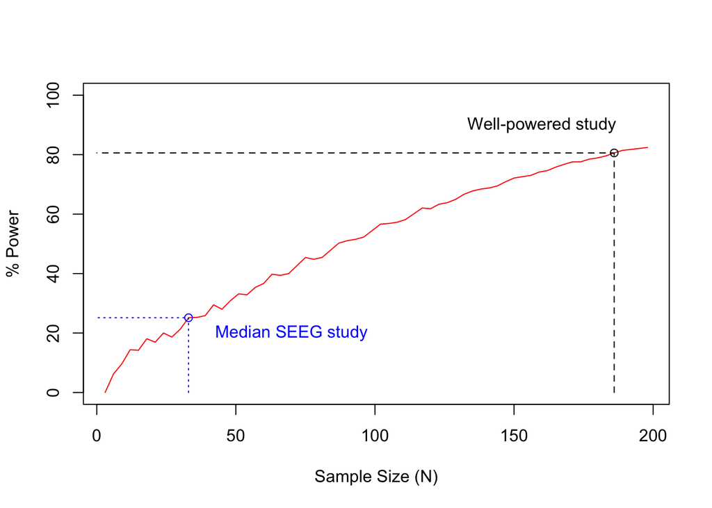

**Figure 1: Power as a function of sample size.** Assuming 2:1 allocation, a study would need 186 subjects (124 vs. 62) to have 80% statistical power to detect a difference in seizure freedom of 66.9%in group 1 and 45.5% in group 2. However, the median SEEG study only has around 24% power to detect this difference. For 2:1 allocation, this corresponds to a sample size of 33 (22 vs. 11).

Interestingly, the exact power calculation does not increase monotonically with increasing sample size. I think that is because the Chi-square test relies on a Gaussian approximation which doesn’t apply for small sample sizes, and because for some values the percentages fall in between the discrete bins.